# Credit Approval Data Set

```python
import pandas as pd
import numpy as np
#from google.colab import drive
import matplotlib.pyplot as plt
import seaborn as sns

#drive.mount('/content/gdrive')
```

# Descrição dos Dados

Fonte dos dados: https://archive.ics.uci.edu/ml/datasets/Credit+Approval

Os dados trabalhados dizem a respeito de pedidos de cartões de crédito. Todos os nomes de atributos e valores foram alterados para símbolos sem sentido para proteger a confidencialidade dos dados.

Este conjunto de dados possui uma boa mistura de atributos: contínuos, nominais com pequenos números de valores, e nominais com maior número de valores. Existem também alguns dados nulos.

O problema a ser tratado com esse dataset é um problema de classificação, a variável resposta é a A16, um pedido de cartão pode ser classificado como + (aprovado) ou como - (reprovado).

Informações sobre as variáveis

```
    A1: b, a.
    A2: continuous.
    A3: continuous.
    A4: u, y, l, t.
    A5: g, p, gg.
    A6: c, d, cc, i, j, k, m, r, q, w, x, e, aa, ff.
    A7: v, h, bb, j, n, z, dd, ff, o.
    A8: continuous.
    A9: t, f.
    A10:    t, f.
    A11:    continuous.
    A12:    t, f.
    A13:    g, p, s.
    A14:    continuous.
    A15:    continuous.
```

Ao procurar online sobre o significado das variáveis encontra-se a seguinte resposta:

```
'data.frame':   689 obs. of  16 variables:
 $ A1 Male          : num  1 1 0 0 0 0 1 0 0 0 ...
 $ A2 Age           : chr  "58.67" "24.50" "27.83" "20.17" ...
 $ A3 Debt          : num  4.46 0.5 1.54 5.62 4 ...
 $ A4 Married       : chr  "u" "u" "u" "u" ...
 $ A5 BankCustomer  : chr  "g" "g" "g" "g" ...
 $ A6 EducationLevel: chr  "q" "q" "w" "w" ...
 $ A7 Ethnicity     : chr  "h" "h" "v" "v" ...
 $ A8 YearsEmployed : num  3.04 1.5 3.75 1.71 2.5 ...
 $ A9 PriorDefault  : num  1 1 1 1 1 1 1 1 1 0 ...
 $ A10 Employed      : num  1 0 1 0 0 0 0 0 0 0 ...
 $ A11 CreditScore   : num  6 0 5 0 0 0 0 0 0 0 ...
 $ A12 DriversLicense: chr  "f" "f" "t" "f" ...
 $ A13 Citizen       : chr  "g" "g" "g" "s" ...
 $ A14 ZipCode       : chr  "00043" "00280" "00100" "00120" ...
 $ A15 Income        : num  560 824 3 0 0 ...
 $ A16 Approved      : chr  "+" "+" "+" "+" ...
```

## Importando e Explorando os Dados

```python
data = pd.read_csv('data/crx.data', sep = ",")

# Visualização dos dados
print(data.shape)
data.head(5)
```

```
(690, 15)
```

|  | a1 | a2 | a3 | a4 | a5 | a6 | a7 | a8 | a9 | a10 | a11 | a12 | a13 | a14 | a15 |
| --- | --- | --- | --- | --- | --- | --- | --- | --- | --- | --- | --- | --- | --- | --- | --- |
| b | 30.83 | 0.000 | u | g | w | v | 1.25 | t | t | 1 | f | g | 00202 | 0 | + |
| a | 58.67 | 4.460 | u | g | q | h | 3.04 | t | t | 6 | f | g | 00043 | 560 | + |
| a | 24.50 | 0.500 | u | g | q | h | 1.50 | t | f | 0 | f | g | 00280 | 824 | + |
| b | 27.83 | 1.540 | u | g | w | v | 3.75 | t | t | 5 | t | g | 00100 | 3 | + |
| b | 20.17 | 5.625 | u | g | w | v | 1.71 | t | f | 0 | f | s | 00120 | 0 | + |

Ao visualizar os dados nota-se que a variável A1 (como descrita no arquivo crx.names) não está representando duas classes: A1: b, a.

E sim uma variável contínua, que deveria ser a A2, os valores de a, b acabaram indo para o index, iremos corrigir isso e renomear as variáveis.

```python
data = data.rename_axis('A1').reset_index()
data.head(5)
```

|  | A1 | a1 | a2 | a3 | a4 | a5 | a6 | a7 | a8 | a9 | a10 | a11 | a12 | a13 | a14 | a15 |
| --- | --- | --- | --- | --- | --- | --- | --- | --- | --- | --- | --- | --- | --- | --- | --- | --- |
| 0 | b | 30.83 | 0.000 | u | g | w | v | 1.25 | t | t | 1 | f | g | 00202 | 0 | + |
| 1 | a | 58.67 | 4.460 | u | g | q | h | 3.04 | t | t | 6 | f | g | 00043 | 560 | + |
| 2 | a | 24.50 | 0.500 | u | g | q | h | 1.50 | t | f | 0 | f | g | 00280 | 824 | + |
| 3 | b | 27.83 | 1.540 | u | g | w | v | 3.75 | t | t | 5 | t | g | 00100 | 3 | + |
| 4 | b | 20.17 | 5.625 | u | g | w | v | 1.71 | t | f | 0 | f | s | 00120 | 0 | + |

Agora iremos renomear todas as colunas

```python
d = {'A1' : 'A1',	'a1':'A2',	'a2':'A3',	'a3':'A4',	'a4':'A5',	'a5':'A6',	'a6':'A7',	'a7':'A8',	'a8':'A9',	'a9':'A10',	'a10':'A11',	'a11':'A12',	'a12':'A13',	'a13':'A14',	'a14':'A15',	'a15': 'A16'}

data.rename(columns = d, inplace = True)
data.head(5)
```

|  | A1 | A2 | A3 | A4 | A5 | A6 | A7 | A8 | A9 | A10 | A11 | A12 | A13 | A14 | A15 | A16 |
| --- | --- | --- | --- | --- | --- | --- | --- | --- | --- | --- | --- | --- | --- | --- | --- | --- |
| 0 | b | 30.83 | 0.000 | u | g | w | v | 1.25 | t | t | 1 | f | g | 00202 | 0 | + |
| 1 | a | 58.67 | 4.460 | u | g | q | h | 3.04 | t | t | 6 | f | g | 00043 | 560 | + |
| 2 | a | 24.50 | 0.500 | u | g | q | h | 1.50 | t | f | 0 | f | g | 00280 | 824 | + |
| 3 | b | 27.83 | 1.540 | u | g | w | v | 3.75 | t | t | 5 | t | g | 00100 | 3 | + |
| 4 | b | 20.17 | 5.625 | u | g | w | v | 1.71 | t | f | 0 | f | s | 00120 | 0 | + |

```python
# Droppando duplicatas caso existam
print(data.shape)
data.drop_duplicates(inplace= True)
print(data.shape)
```

```
(690, 16)
(690, 16)
```

### Média, desvio padrão, min, max e quartis de todas as variáveis numéricas

```python
data.describe()
```

|  | A3 | A8 | A11 | A15 |
| --- | --- | --- | --- | --- |
| count | 690.000000 | 690.000000 | 690.00000 | 690.000000 |
| mean | 4.758725 | 2.223406 | 2.40000 | 1017.385507 |
| std | 4.978163 | 3.346513 | 4.86294 | 5210.102598 |
| min | 0.000000 | 0.000000 | 0.00000 | 0.000000 |
| 25% | 1.000000 | 0.165000 | 0.00000 | 0.000000 |
| 50% | 2.750000 | 1.000000 | 0.00000 | 5.000000 |
| 75% | 7.207500 | 2.625000 | 3.00000 | 395.500000 |
| max | 28.000000 | 28.500000 | 67.00000 | 100000.000000 |

Nem todas as variáveis descritas como contínuas na descrição do dataset foram lidas como contínuas pelo python, isso será corrigido. No dataset os valores nulos estão sendo representados por ?, portanto iremos substitui-los pelo valor nulo do numpy para ficar mais fácil trabalhar com eles

```python
data = data.replace('?', np.nan)

data["A2"] = data["A2"].astype(np.float16)
a14_before = data["A14"]
data["A14"] = data["A14"].astype(np.float16)
data_sem_nulos = data.dropna(subset=['A2', 'A3', 'A8', 'A11', 'A14', 'A15'])
data_sem_nulos.describe()
```

|  | A2 | A3 | A8 | A11 | A14 | A15 |
| --- | --- | --- | --- | --- | --- | --- |
| count | 666.000000 | 666.000000 | 666.000000 | 666.000000 | 666.00 | 666.000000 |
| mean | 31.562500 | 4.798078 | 2.222320 | 2.459459 | inf | 998.584084 |
| std | 11.921875 | 5.005309 | 3.347599 | 4.929794 | inf | 5202.975198 |
| min | 13.750000 | 0.000000 | 0.000000 | 0.000000 | 0.00 | 0.000000 |
| 25% | 22.601562 | 1.010000 | 0.165000 | 0.000000 | 75.25 | 0.000000 |
| 50% | 28.500000 | 2.750000 | 1.000000 | 0.000000 | 160.00 | 5.000000 |
| 75% | 38.250000 | 7.207500 | 2.585000 | 3.000000 | 271.00 | 399.000000 |
| max | 80.250000 | 28.000000 | 28.500000 | 67.000000 | 2000.00 | 100000.000000 |

É interessante notar que o desvio padrão de muitas das variáveis chega a ser maior que sua média.

### Visualizando a distribuição das classes na variável resposta

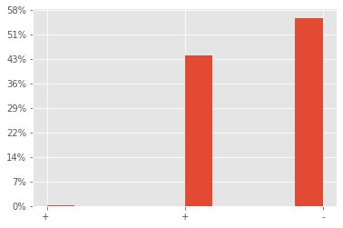

```python
from matplotlib.ticker import PercentFormatter

plt.style.use('ggplot')
plt.hist(data["A16"])
plt.gca().yaxis.set_major_formatter(PercentFormatter(690))
```

Notamos que existem algumas instâncias onde a classe "+" está com espaços vazios na string, fazendo com que o histograma indique que "+" e "+ " são duas classes diferentes, o que não é o caso, portanto iremos realizar um trim nessa variável.

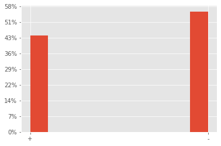

```python
def strp(a):
  return a.strip()

data["A16"] = data["A16"].apply(strp)

plt.style.use('ggplot')
plt.hist(data["A16"])
plt.gca().yaxis.set_major_formatter(PercentFormatter(690))
```

```python
data.A16.value_counts(normalize=True)
```

```
-    0.555072
+    0.444928
Name: A16, dtype: float64
```

Assim vemos que os dados estão distribuidos quase igualmente entre as duas classes, sendo os pedidos aprovados detentores de 44,5% do total e os reprovados de 55,5%

## Dados Nulos

Nesse gráfico o que está preenchido com preto são dados não nulos, além disso há uma barra no lado direito deste diagrama. Este é um gráfico de linha para a integridade dos dados de cada linha.

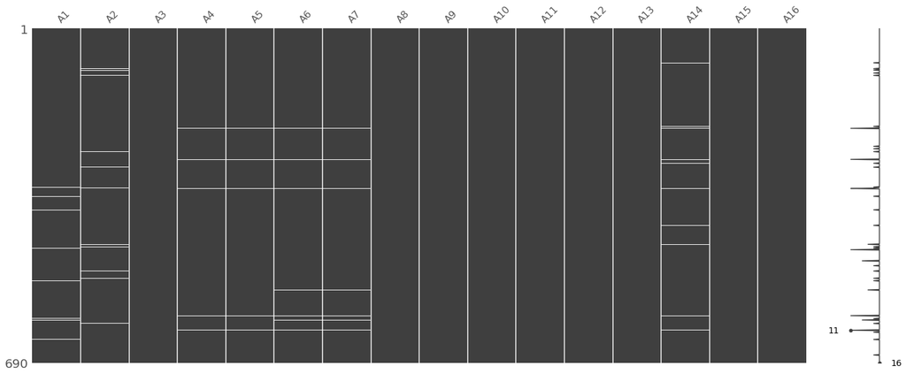

```python
import missingno as msno
msno.matrix(data)
```

Dessa forma podemos visualizar que existem poucos dados faltantes nesse conjunto de dados, desse modo pode ser interessante apenas retirar-los pois não haveria uma perda grande de informação, ou retirar apenas aqueles que estão em variáveis categóricas e preencher com a média da coluna aqueles que se encontram em variáveis numéricas. Para essa análise preferimos retirar apenas aqueles que estão em variáveis categóricas e preencher com a média da coluna aqueles que se encontram em variáveis numéricas.

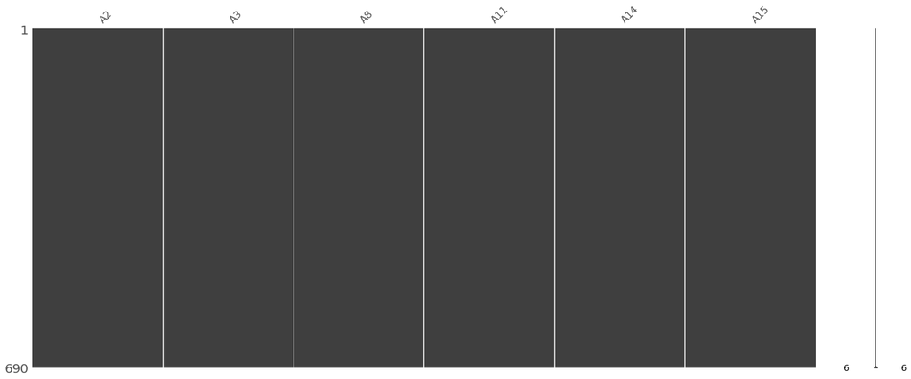

```python
data_cont = data[['A2', 'A3', 'A8', 'A11', 'A14', 'A15']]
data_cont.fillna(data_cont.mean(), inplace = True)
msno.matrix(data_cont)

data["A2"] = data_cont["A2"]
data["A3"] = data_cont["A3"]
data["A8"] = data_cont["A8"]
data["A11"] = data_cont["A11"]
data["A14"] = data_cont["A14"]
data["A15"] = data_cont["A15"]
```

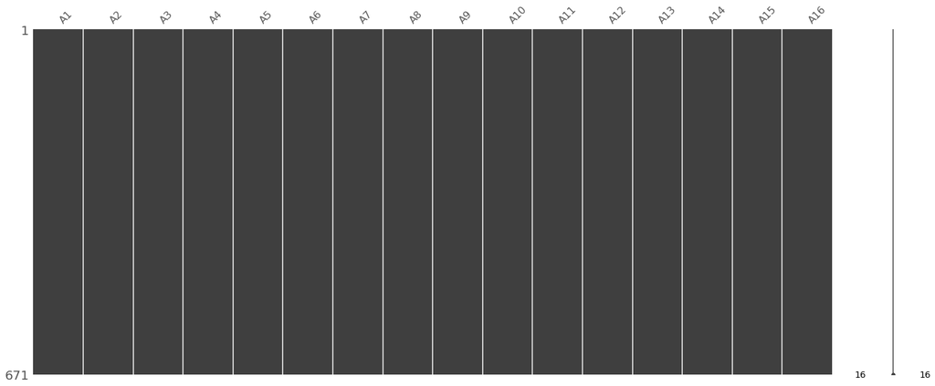

```python
data = data.dropna()
msno.matrix(data)
```

## Visualizando a relação das variáveis categóricas com a variável resposta

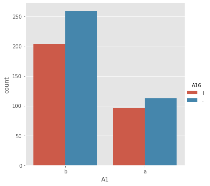

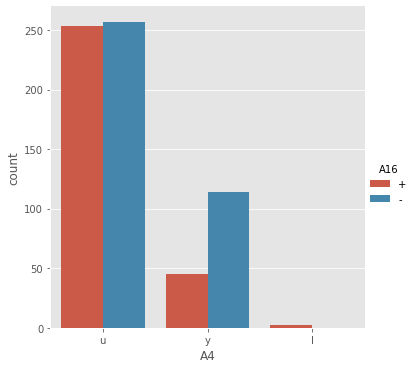

```python
sns.catplot(x="A1", kind="count", hue="A16", data=data)
sns.catplot(x="A4", kind="count", hue="A16", data=data)
```

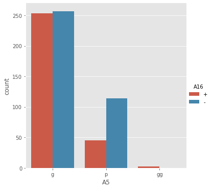

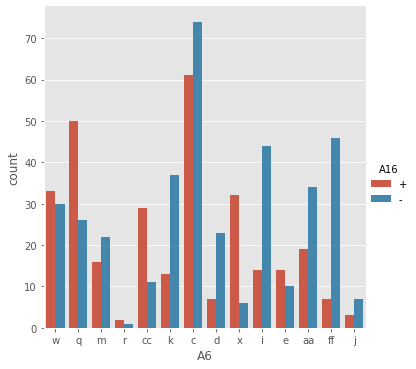

```python
sns.catplot(x="A5", kind="count", hue="A16", data=data)
sns.catplot(x="A6", kind="count", hue="A16", data=data)
```

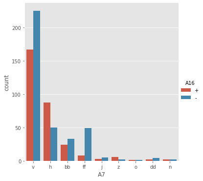

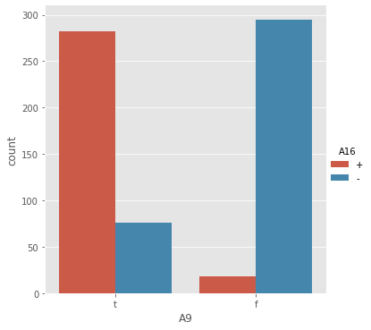

```python
sns.catplot(x="A7", kind="count", hue="A16", data=data)
sns.catplot(x="A9", kind="count", hue="A16", data=data)
```

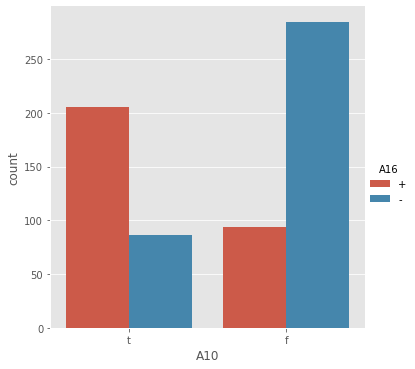

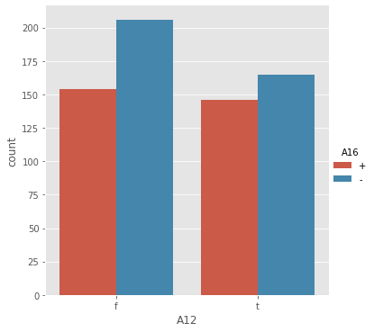

```python
sns.catplot(x="A10", kind="count", hue="A16", data=data)
sns.catplot(x="A12", kind="count", hue="A16", data=data)
```

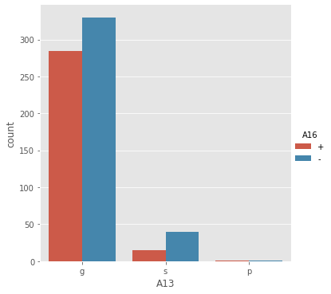

```python
sns.catplot(x="A13", kind="count", hue="A16", data=data)
```

Pelos gráficos é possível notar uma relação de possível correlação entre a A9 e A16 e entre a A10 e A16, tornando A9 e A10 variáveis interessantes.

## Plotando as variáveis contínuas

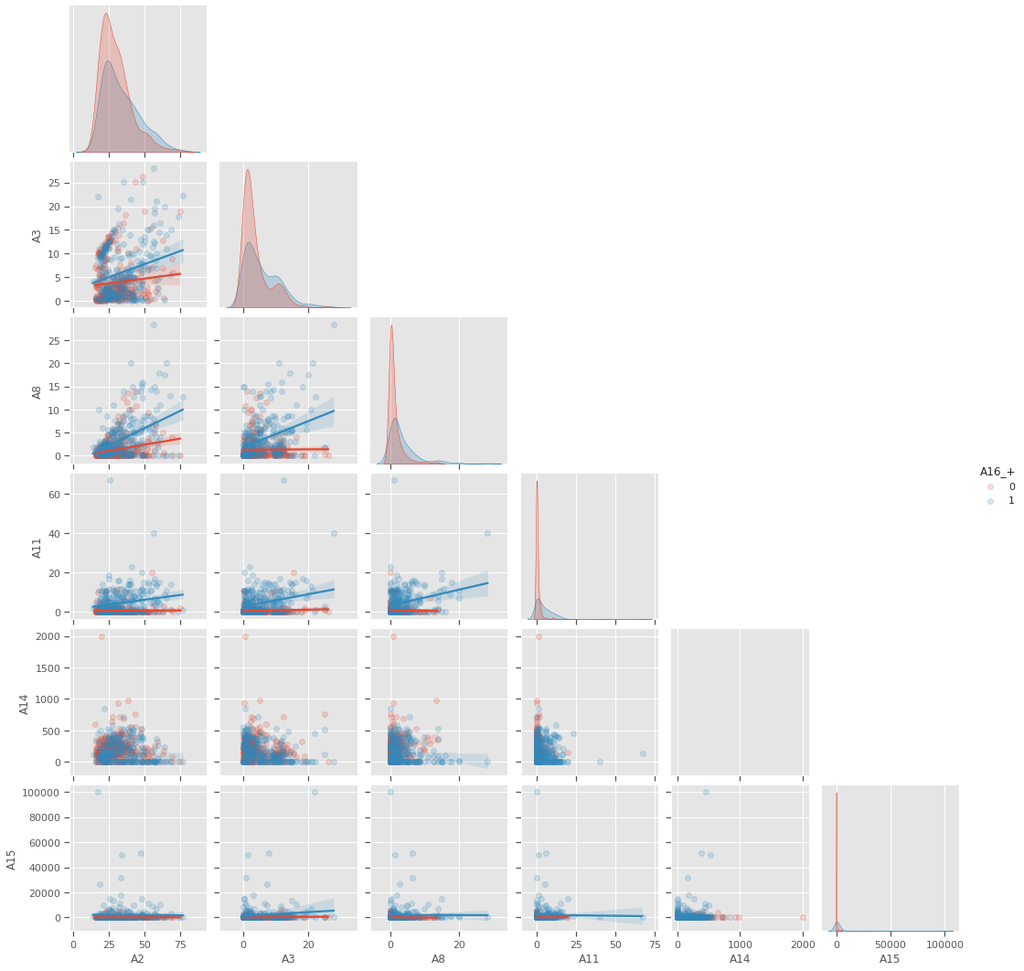

```python
variaveis_pertinentes = data[["A16", "A2", "A3", "A8", "A11","A14", "A15"]].copy()
variaveis_pertinentes = pd.get_dummies(variaveis_pertinentes, columns=["A16"])
variaveis_pertinentes.drop(["A16_-"], axis=1, inplace=True) # Manter ambas as variáveis seria redundante
sns.set(style="ticks", color_codes=True)
plt.style.use('ggplot')
# Plotando a distribuição em pares das variáveis pertinentes e seus histogramas
plt.figure(figsize=(8,8))
sns.pairplot(variaveis_pertinentes, hue="A16_+", corner=True, kind="reg", diag_kind="kde", plot_kws={'scatter_kws': {'alpha': 0.2}})
plt.show()
```

As variáveis contínuas, possuem uma distribuição bastante concentrada nos valores mais à esquerda do gráfico. As A3 e A2 são as que tem ainda uma distribuição mais "uniforme". É possível ver que as classes se misturam bastante em todas combinações de variáveis e é difícil fazer sua distinção.

## Visualizando a Matriz de Correlação

```python
# Visualizando a matriz de correlação
corr = variaveis_pertinentes.corr()
corr.style.background_gradient(cmap='coolwarm').set_precision(9)
```

|  | A2 | A3 | A8 | A11 | A14 | A15 | A16_+ |
| --- | --- | --- | --- | --- | --- | --- | --- |
| A2 | 1.000000000 | 0.213260692 | 0.411986588 | 0.196309299 | -0.082654238 | 0.020680641 | 0.175263720 |
| A3 | 0.213260692 | 1.000000000 | 0.291674473 | 0.266505652 | -0.224197224 | 0.121717980 | 0.205815974 |
| A8 | 0.411986588 | 0.291674473 | 1.000000000 | 0.318445396 | -0.073289648 | 0.049433093 | 0.324797935 |
| A11 | 0.196309299 | 0.266505652 | 0.318445396 | 1.000000000 | -0.118362561 | 0.061737704 | 0.409645374 |
| A14 | -0.082654238 | -0.224197224 | -0.073289648 | -0.118362561 | 1.000000000 | 0.070575781 | -0.094302093 |
| A15 | 0.020680641 | 0.121717980 | 0.049433093 | 0.061737704 | 0.070575781 | 1.000000000 | 0.177212567 |
| A16_+ | 0.175263720 | 0.205815974 | 0.324797935 | 0.409645374 | -0.094302093 | 0.177212567 | 1.000000000 |

A8 e A11 são as variáveis com maior correlação com a variável resposta A16_+, no entanto suas correlações não chegam a ser fortes.

```python
data.head()
```

|  | A1 | A2 | A3 | A4 | A5 | A6 | A7 | A8 | A9 | A10 | A11 | A12 | A13 | A14 | A15 | A16 |
| --- | --- | --- | --- | --- | --- | --- | --- | --- | --- | --- | --- | --- | --- | --- | --- | --- |
| 0 | b | 30.828125 | 0.000 | u | g | w | v | 1.25 | t | t | 1 | f | g | 202.0 | 0 | + |
| 1 | a | 58.656250 | 4.460 | u | g | q | h | 3.04 | t | t | 6 | f | g | 43.0 | 560 | + |
| 2 | a | 24.500000 | 0.500 | u | g | q | h | 1.50 | t | f | 0 | f | g | 280.0 | 824 | + |
| 3 | b | 27.828125 | 1.540 | u | g | w | v | 3.75 | t | t | 5 | t | g | 100.0 | 3 | + |
| 4 | b | 20.171875 | 5.625 | u | g | w | v | 1.71 | t | f | 0 | f | s | 120.0 | 0 | + |

# Preparação dos dados

## O problema da variável A14

Ao ler a documentação dos dados é possível notar que a variável A14 foi descrita como sendo contínua, no entanto ela aparenta ser uma variável de endereço postal, portanto existe perda de informação ao transformá-la em contínua, ela seria categórica e deve ser tratada de outra maneira, portanto voltará ao seu estado inicial.

```python
data.A14.value_counts()
```

```
0.0      131
120.0     35
200.0     34
160.0     33
100.0     30
        ...
93.0       1
17.0       1
121.0      1
52.0       1
395.0      1
Name: A14, Length: 167, dtype: int64
```

```python
a14_before.value_counts()
```

```
00000    132
00120     35
00200     35
00160     34
00080     30
        ...
00288      1
00204      1
00170      1
00395      1
00230      1
Name: A14, Length: 170, dtype: int64
```

```python
a14_before.describe()
```

```
count       677
unique      170
top       00000
freq        132
Name: A14, dtype: object
```

Em sua forma atual, com 170 valores categóricos únicos nessa coluna de "código postal", um modelo de aprendizagem de máquina não pode extrair nenhuma das informações úteis contidas em cada código postal para avaliar uma relação com o preço.

Dentro de cada uma destas categorias existe uma seleção única de fatores imobiliários significativos como parques, escolas, cafés, lojas, mercearias, acesso a trânsito e estradas principais, além disso também podem ser extraídas informações sobre renda média da área, todos esses novos fatores poderiam ser úteis para um modelo.

Existem diversas formas de fazer com que as informações de código postal sejam úteis, pode ser possível extrair a latitude e longitude das mesmas e realizar um cruzamento com bases externas populacionais (como as do IBGE), podemos também agrupar os códigos postais de uma mesma área e criar classes com eles ou podemos realizar o one hot enconding (que será tratado adiante) da mesma forma que em qualquer outra variável categórica.

Como os dados estão anonimizados é difícil extrair muitas informações ou realizar agrupamentos com a variável de código postal, dada essa limitação poderiamos apenas realizar o procedimento de one hot encoding nela, assim como em outras variáveis categóricas, no entanto optamos por exclui-la do dataset para que seja mais fácil enxergar depois quais são as variáveis mais importantes para a classificação, dado que seriam criadas muitas colunas com o one hot enconding desse dado.

```python
data.A14 = a14_before
data.drop(["A14"], inplace=True, axis=1)
```

## Convertendo dados categóricos em dados numéricos

### Por que converter?

Dados categóricos são variáveis que contêm valores de rótulos ao invés de valores numéricos, seu número de valores possíveis é muitas vezes limitado a um conjunto fixo.

As variáveis "A1", "A4", "A5", "A6", "A7", "A9", "A10", "A12", "A13", "A14" do nosso conjunto de dados são categóricas.

Alguns algoritmos podem funcionar diretamente com dados categóricos, por exemplo, uma árvore de decisão pode ser aprendida diretamente com dados categóricos sem necessidade de transformação de dados (dependendo de uma implementação específica). No entanto muitos algoritmos de aprendizagem de máquina (regressões por exemplo) não podem operar diretamente com dados nominais, eles exigem que todas as variáveis de entrada e de saída sejam numéricas.

Dessa maneira é interessante que, para não perdermos as informações contidas nos dados categóricos, eles sejam convertidos para uma forma numérica.

### Pode ser feito de duas maneiras:

1. Integer Encoding
2. One-Hot Encoding

### 1. Integer Encoding

Para cada valor único de uma categoria é atribuído um valor inteiro.

Em nossa base por exemplo, na coluna A16, podemos atribuir 1 a "+" (aprovado) e "-" (reprovado) seria 0. Isto é chamado de codificação de etiqueta ou Integer Encoding e é facilmente reversível. Para algumas variáveis, como é o caso da nossa variável resposta isto já é suficiente.

Nesse caso os valores inteiros têm uma relação de ordenação natural entre si e alguns algoritmos de aprendizagem da máquina são capazes de entender e aproveitar esta relação. Portanto é interessante manter o 1 como aprovado e 0 como reprovado pois aprovado é uma classe "superior" à reprovado.

```python
data["A16"] = data["A16"].replace('+', 1)
data["A16"] = data["A16"].replace('-', 0)
```

Nas seguintes variáveis, dada a informação que temos sobre o que significam e dado que temos 2 classes para cada (t ou f, ou seja true ou false) podemos também realizar o integer encoding.

```python
data["A9"] = data["A9"].replace('t', 1)
data["A9"] = data["A9"].replace('f', 0)
```

```python
data["A10"] = data["A10"].replace('t', 1)
data["A10"] = data["A10"].replace('f', 0)
```

```python
data["A12"] = data["A12"].replace('t', 1)
data["A12"] = data["A12"].replace('f', 0)
```

### 2. One-Hot Encoding

Para variáveis categóricas onde não existe relação ordinal, a integer encoding não é suficiente. Ao usar esse tipo de codificação permitiríamos que qualquer modelo utilizado assumisse uma ordenação natural entre as categorias, o que pode resultar em um desempenho ruim ou resultados inesperados com previsões "no meio do caminho" entre categorias.

Dessa forma podemos usar o one-hot encoding e criar uma variável binária para cada classe da variável categórica. Por exemplo a variável A4 possui três valores, u, y e l, quando a classe for u será colocado 1 na variável nova a4_u e 0 nas demais.

| a4_u | a4_y | a4_l |
| --- | --- | --- |
| 1 | 0 | 0 |
| 0 | 1 | 0 |
| 0 | 0 | 1 |

Também é interessante remover colunas redundantes dos nossos dados, por exemplo, com as informações das variáveis u e y já podemos inferir o valor da l, portanto ela não é necessária na nossa base de dados e ao final da transformação da coluna A4 em dados numéricos as colunas finais poderiam ser apenas:

| a4_u | a4_y |
| --- | --- |
| 1 | 0 |
| 0 | 1 |
| 0 | 0 |

sem haver perda alguma de informação.

Não há informação o suficiente sobre as variáveis restantes para presumir que existe alguma relação ordinal entre as classes, portanto iremos assumir que para o restante das variáveis categóricas da nossa base é mais interessante utilizar o one-hot encoding.

```python
data_dummified = pd.get_dummies(data, columns = ["A1", "A4", "A5", "A6", "A7", "A13"], drop_first= True)
```

### Observando a matriz de correlação agora com as transformações nas variáveis

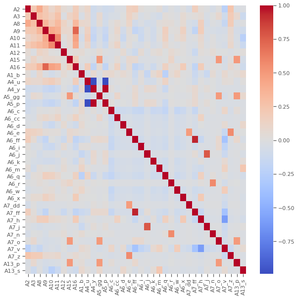

```python
# Visualizando a matriz de correlação
corr = data_dummified.corr()

plt.figure(figsize=(10,10))
sns.heatmap(corr, cmap= 'coolwarm')
plt.show()
```

A matriz possui bastante colunas agora, o que torna sua visualização difícil, portanto iremos buscar na coluna A16 quais seriam as variáveis com maior correlação.

```python
corr["A16"].abs().sort_values()
```

```
A6_c     0.004803
A13_p    0.005818
A7_o     0.005818
A7_n     0.008240
A6_m     0.012833
A7_j     0.015928
A1_b     0.019472
A7_dd    0.021734
A6_r     0.029596
A6_j     0.036389
A12      0.041799
A6_w     0.049668
A7_v     0.050240
A6_e     0.052775
A5_gg    0.060803
A7_z     0.066922
A6_d     0.093011
A13_s    0.104792
A6_k     0.106776
A6_i     0.127269
A6_cc    0.140731
A6_q     0.151529
A2       0.175264
A4_u     0.175350
A15      0.177213
A4_y     0.183900
A5_p     0.183900
A6_ff    0.185547
A7_ff    0.187976
A7_h     0.191465
A6_x     0.194659
A3       0.205816
A8       0.324798
A11      0.409645
A10      0.456158
A9       0.732671
A16      1.000000
Name: A16, dtype: float64
```

Dessa maneira vemos que A10 e A9 seriam as variáveis que possuem maior correlação com A16

```python
data_dummified.head()
```

|  | A2 | A3 | A8 | A9 | A10 | A11 | A12 | A15 | A16 | A1_b | ... | A7_dd | A7_ff | A7_h | A7_j | A7_n | A7_o | A7_v | A7_z | A13_p | A13_s |
| --- | --- | --- | --- | --- | --- | --- | --- | --- | --- | --- | --- | --- | --- | --- | --- | --- | --- | --- | --- | --- | --- |
| 0 | 30.828125 | 0.000 | 1.25 | 1 | 1 | 1 | 0 | 0 | 1 | 1 | ... | 0 | 0 | 0 | 0 | 0 | 0 | 1 | 0 | 0 | 0 |
| 1 | 58.656250 | 4.460 | 3.04 | 1 | 1 | 6 | 0 | 560 | 1 | 0 | ... | 0 | 0 | 1 | 0 | 0 | 0 | 0 | 0 | 0 | 0 |
| 2 | 24.500000 | 0.500 | 1.50 | 1 | 0 | 0 | 0 | 824 | 1 | 0 | ... | 0 | 0 | 1 | 0 | 0 | 0 | 0 | 0 | 0 | 0 |
| 3 | 27.828125 | 1.540 | 3.75 | 1 | 1 | 5 | 1 | 3 | 1 | 1 | ... | 0 | 0 | 0 | 0 | 0 | 0 | 1 | 0 | 0 | 0 |
| 4 | 20.171875 | 5.625 | 1.71 | 1 | 0 | 0 | 0 | 0 | 1 | 1 | ... | 0 | 0 | 0 | 0 | 0 | 0 | 1 | 0 | 0 | 1 |

5 rows × 37 columns

## Normalizando dados contínuos

A normalização é uma técnica frequentemente aplicada como parte da preparação de dados para a aprendizagem de máquina. O objetivo da normalização é mudar os valores das colunas numéricas do conjunto de dados para uma escala comum, sem distorcer as diferenças nas faixas de valores. Para a aprendizagem de máquina nem todo conjunto de dados requer normalização, ela só é necessária quando as colunas possuem faixas de valores diferentes.

Por exemplo, considerando o nosso conjunto de dados, a variável A2 e a A3, A2 varia de aproximandamente 13 até 76, com média de 31.46 e desvio padrão de 11.70. Enquanto A3 varia de 0 até 28, com média de 4.83 e desvio padrão de 5.0006. Portanto podemos afirmar que estas duas características estão em faixas diferentes, quando fazemos mais análises, como a regressão linear multivariada, por exemplo, é possível. que A2 influenciará o resultado mais devido a seu maior valor. Mas isto não significa necessariamente que seja mais importante como um preditor.

Uma observação importante é que a normalização deve ser feita após a divisão dos dados entre o conjunto de treinamento e o conjunto de testes, normalizando separadamente ambos os conjuntos.

Devemos fazer isso porque o conjunto de teste desempenha o papel de dados novos e invisíveis, portanto não deve ser acessível na fase de treinamento. Usar qualquer informação (média, máximo, mínimo, desvio padrão) proveniente do conjunto de teste antes ou durante o treinamento é um viés potencial na avaliação do desempenho.

## Conjunto de treino e conjunto de testes

```python
from sklearn.model_selection import train_test_split
from sklearn.preprocessing import MinMaxScaler

X = data_dummified.drop("A16", axis=1)
y = data_dummified["A16"]

X_train, X_test, y_train, y_test = train_test_split(X, y, test_size=0.33, random_state=123)

## Normalizando os dados
scaler = MinMaxScaler()

scaler.fit(X_train)

X_train = scaler.transform(X_train)
X_test = scaler.transform(X_test)
```

```python
X_train
```

```
array([[0.14869323, 0.08928571, 0.15789474, ..., 0.        , 0.        ,
        0.        ],
       [0.42197412, 0.23214286, 0.01754386, ..., 0.        , 0.        ,
        0.        ],
       [0.01065719, 0.27232143, 0.00438596, ..., 0.        , 0.        ,
        0.        ],
       ...,
       [0.12585638, 0.00607143, 0.00298246, ..., 0.        , 0.        ,
        1.        ],
       [0.18117229, 0.46428571, 0.        , ..., 0.        , 0.        ,
        0.        ],
       [0.12433393, 0.10714286, 0.04526316, ..., 0.        , 0.        ,
        0.        ]])
```

```python
X_test
```

```
array([[0.09870591, 0.08339286, 0.01754386, ..., 0.        , 0.        ,
        1.        ],
       [0.13651358, 0.41071429, 0.10526316, ..., 0.        , 0.        ,
        0.        ],
       [0.42755646, 0.055     , 0.12280702, ..., 0.        , 0.        ,
        0.        ],
       ...,
       [0.23141335, 0.04464286, 0.06140351, ..., 0.        , 0.        ,
        0.        ],
       [0.4818574 , 0.25      , 0.05701754, ..., 0.        , 0.        ,
        0.        ],
       [0.34483634, 0.02678571, 0.02052632, ..., 0.        , 0.        ,
        0.        ]])
```

## Funções Auxiliares

### Stratified K-Fold

Realiza um K-Fold estratificado e normaliza os dados nesse processo

```python
from sklearn.model_selection import StratifiedKFold
from sklearn.utils import shuffle

def KFolds_norm(df_all, model):

  acc_list = []
  conf_matrix_list = []
  f1_list = []
  class_repo_list = []
  estimator_list = []

  df = shuffle(df_all)
  X = df.drop("A16", axis=1)
  y = df["A16"]

  X = X.values
  y = y.values


  i = 0
  kf = StratifiedKFold(n_splits=10,random_state=11, shuffle=True)
  kf.get_n_splits(X,y)

  print(kf)

  for train_index, test_index in kf.split(X,y):
    scaler = MinMaxScaler()

    X_train, X_test = X[train_index], X[test_index]
    y_train, y_test = y[train_index], y[test_index]


    scaler.fit(X_train)

    X_train = scaler.transform(X_train)
    X_test = scaler.transform(X_test)

    i = i + 1


    print("--------------------------------------------------------")
    print("Fold número: ", i)
    print("Tamanho do X_train: {}".format(X_train.shape))

    modelo = model
    modelo.fit(X_train,y_train)

    y_pred = modelo.predict(X_test)
    acc = accuracy_score(y_test, y_pred)
    class_repo = classification_report(y_test, y_pred)
    f1 = f1_score(y_test, y_pred)
    conf_matrix = confusion_matrix(y_test, y_pred,labels=[0,1])
    print("Acurácia: ", acc)
    print("f1-score: ", f1)

    acc_list.append(acc)
    conf_matrix_list.append(conf_matrix)
    f1_list.append(f1)
    class_repo_list.append(class_repo)
    estimator_list.append(modelo)

  print("Terminado")



  return acc_list, conf_matrix_list, f1_list, class_repo_list, estimator_list
```

### Boxplot Resultados

```python
def boxplot_results(acc_list, f1_list):
  results_kfold = pd.DataFrame()
  results_kfold["mean"] = acc_list
  results_kfold["method"] = "Accuracy"

  results_kfold1 = pd.DataFrame()
  results_kfold1["mean"] = f1_list
  results_kfold1["method"] = "f1"

  results_kfold = pd.concat([results_kfold,results_kfold1])
  results_kfold.head()

  fig, ax = plt.subplots(figsize=(12,10))
  plt.ylim(0.70, 0.95)
  ax = sns.boxplot(x="method", y="mean", hue="method", data=results_kfold, palette="Set1")
  plt.show()
```

### Matriz de confusão

```python
def conf_matrix(conf_matrix, list_scores):
  index_best = list_scores.index(max(list_scores))
  conf_matrix_best = conf_matrix[index_best]

  fig, ax = plt.subplots(figsize=(15,10))
  sns.set(font_scale=1.4) # for label size
  sns.heatmap(conf_matrix_best, annot=True, annot_kws={"size": 10}) # font size

  plt.show()
```

### GridSearch

```python
def grid_search(model, param_grid, n_folds, X, y):
  scoring = {'PRECISION': 'precision', 'F1': 'f1'}
  #use gridsearch to test all values for n_neighbors
  gscv = GridSearchCV(model, param_grid, cv=n_folds, scoring=scoring, refit='F1')
  #fit model to data
  gscv.fit(X, y)
  return gscv.best_params_, gscv.best_score_, gscv.cv_results_
```

# Métricas de avaliação

### Recall

Segundo o Google Developers para Machine Learning [https://developers.google.com/machine-learning/crash-course/classification/precision-and-recall] , entendemos que o recall responde a seguinte pergunta: qual proporção de positivos foi identificados corretamente? Em outras palavras, quão bom meu modelo é para prever positivos. Ele é definido como a razão entre verdadeiros positivos sobre a soma de verdadeiros positivos com negativos falsos.

### Precision

Ainda usando o material do Google Developers, precisão é definida como a resposta para a seguinte pergunta: Qual a proporção de identificações positivas foi realmente correta? É a razão entre os verdadeiros positivos sobre verdadeiros positivos + falsos positivos.

### Matriz de Confusão

A matriz de confusão é tabela que mostra as frequências de classificação para cada classe do modelo.

- Verdadeiro positivo (true positive — TP): ocorre quando no conjunto real, a classe que estamos buscando foi prevista corretamente.
- Falso positivo (false positive — FP): ocorre quando no conjunto real, a classe que estamos buscando prever foi prevista incorretamente.
- Verdadeiro negativo (true negative — TN): ocorre quando no conjunto real, a classe que não estamos buscando prever foi prevista corretamente.
- Falso negativo (false negative — FN): ocorre quando no conjunto real, a classe que não estamos buscando prever foi prevista incorretamente.

No nosso problema estamos procurando prever a classe de cartões aprovados

### Accuracy

A acurácia é uma métrica para avaliar os modelos de classificação. A acurácia (accuracy score) é a fração das previsões que nosso modelo acertou:

Número de predições corretas / número de predições em total

Para a classificação binária, a precisão também pode ser calculada em termos de positivos e negativos da seguinte forma:

(TP + TN) / (TP + TN + FP + FN)

A acurácia por si só não conta a história completa quando se trabalha com um conjunto de dados desequilibrado, onde há uma disparidade significativa entre o número de etiquetas positivas e negativas. No entanto como nosso conjunto de dados é relativamente equilibrado é seguro utilizar a acurácia em conjunto com outros métodos.

### f1 score

O f-measure ou f1 score é a média harmônica do precision e recall. Na maioria das situações, você terá um trade-off entre precision e recall. Se seu classificador for otimizado para aumentar um e desfavorecer o outro, a média harmônica diminui rapidamente, no entanto, é maior quando tanto o precision quanto o recall tem valores parecidos.

F-measure tem um significado intuitivo. Ela lhe diz quão preciso é seu classificador (quantas instâncias ele classifica corretamente), bem como quão robusto ele é (ele não perde um número significativo de instâncias).

Com alta precisão, mas baixo recall, seu classificador é extremamente preciso, mas perde um número significativo de instâncias que são difíceis de classificar e isso não seria muito útil. Portanto o f-measure será a métrica principal que iremos utilizar para comparar os algoritmos de classificação.

# Algoritmos de Classificação

## KNN

O algoritmo KNN assume que coisas similares existem em grande proximidade. Em outras palavras, coisas semelhantes estão próximas uma da outra, ele depende desta suposição ser verdadeira o suficiente para que seja útil. O KNN captura a idéia de semelhança (às vezes chamada distância, proximidade ou proximidade) a partir do cálculo da distância entre pontos, a distância em linha reta (também chamada de distância Euclidiana) é uma escolha popular e familiar para calcular a proximidade entre pontos no KNN e, assim, realizar uma tarefa de classificação em diferentes grupos.

```python
from sklearn.neighbors import KNeighborsClassifier
from sklearn.metrics import classification_report, confusion_matrix
from sklearn.metrics import accuracy_score
from sklearn.metrics import f1_score
from sklearn.model_selection import RepeatedStratifiedKFold
from sklearn.model_selection import GridSearchCV
```

### Escolhendo o valor certo para k (número de vizinhos)

Para selecionar o K adequado para nossos dados, executamos o algoritmo KNN várias vezes com diferentes valores de K e escolhemos o K que reduz o número de erros que encontramos, mantendo a capacidade do algoritmo de fazer previsões com precisão quando são fornecidos dados que não foram vistos antes.

1. À medida que diminuimos o valor de K para 1, nossas previsões se tornam menos estáveis. Basta pensar por um minuto, imagine K=1 e temos um ponto de consulta cercado por vários vermelhos e um verde, mas o verde é o único vizinho mais próximo. Razoavelmente, pensaríamos que o ponto de interrogação é provavelmente vermelho, mas porque K=1, KNN prevê incorretamente que o ponto de interrogação é verde.
2. Inversamente, à medida que aumentamos o valor de K, nossas previsões se tornam mais estáveis devido à votação por maioria / média e, portanto, mais propensas a fazer previsões mais precisas (até um certo ponto). Eventualmente, começamos a testemunhar um número crescente de erros. É neste ponto que sabemos que elevamos demais o valor de K.

Iremos variar k entre 3 e 25 para o nosso problema.

```python
data_dummified.A16.value_counts()
```

```
0    371
1    300
Name: A16, dtype: int64
```

```python
X = data_dummified.drop("A16", axis=1)
y = data_dummified["A16"]

X = X.values
y = y.values

knn = KNeighborsClassifier()
best_params, best_score, results = grid_search(knn, {'n_neighbors': range(3,25)},10, X,y)
```

```python
best_score
```

```
0.6536050898992076
```

```python
knn_best = best_params
print("Melhores parâmetros: {}".format(knn_best))
```

```
Melhores parâmetros: {'n_neighbors': 16}
```

### Usando k-fold e normalizando os dados

```python
knn = KNeighborsClassifier(**knn_best)
acc_list, conf_matrix_list, f1_list, class_repo_list, modelos = KFolds_norm(data_dummified, knn)
```

```
StratifiedKFold(n_splits=10, random_state=11, shuffle=True)
--------------------------------------------------------
Fold número:  1
Tamanho do X_train: (603, 36)
Acurácia:  0.8676470588235294
f1-score:  0.8421052631578948
--------------------------------------------------------
Fold número:  2
Tamanho do X_train: (604, 36)
Acurácia:  0.835820895522388
f1-score:  0.8135593220338982
--------------------------------------------------------
Fold número:  3
Tamanho do X_train: (604, 36)
Acurácia:  0.835820895522388
f1-score:  0.8070175438596491
--------------------------------------------------------
Fold número:  4
Tamanho do X_train: (604, 36)
Acurácia:  0.8208955223880597
f1-score:  0.793103448275862
--------------------------------------------------------
Fold número:  5
Tamanho do X_train: (604, 36)
Acurácia:  0.8059701492537313
f1-score:  0.7636363636363636
--------------------------------------------------------
Fold número:  6
Tamanho do X_train: (604, 36)
Acurácia:  0.9104477611940298
f1-score:  0.8928571428571429
--------------------------------------------------------
Fold número:  7
Tamanho do X_train: (604, 36)
Acurácia:  0.8208955223880597
f1-score:  0.7857142857142856
--------------------------------------------------------
Fold número:  8
Tamanho do X_train: (604, 36)
Acurácia:  0.8507462686567164
f1-score:  0.8148148148148148
--------------------------------------------------------
Fold número:  9
Tamanho do X_train: (604, 36)
Acurácia:  0.9104477611940298
f1-score:  0.896551724137931
--------------------------------------------------------
Fold número:  10
Tamanho do X_train: (604, 36)
Acurácia:  0.8656716417910447
f1-score:  0.8421052631578948
Terminado
```

```python
print(max(acc_list))
print(max(f1_list))

dict_results = {}
dict_results['knn_acc'] = max(acc_list)
dict_results['knn_f1'] = max(f1_list)
```

```
0.9104477611940298
0.896551724137931
```

Nosso f1 é de 0.8965

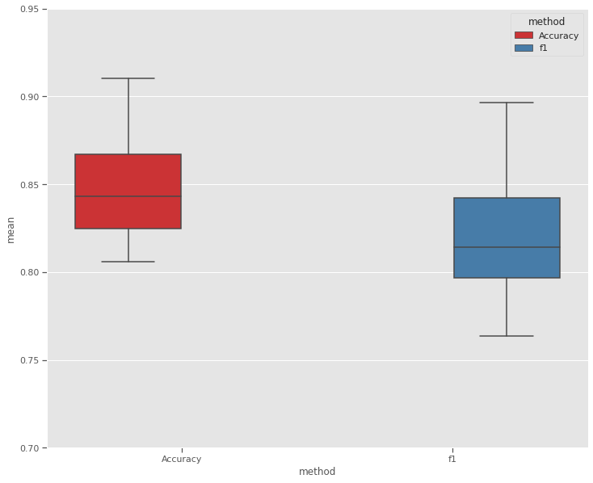

```python
boxplot_results(acc_list, f1_list)
```

Pelo gráfico de boxplot podemos observar que a variância dos scores é baixa no cv

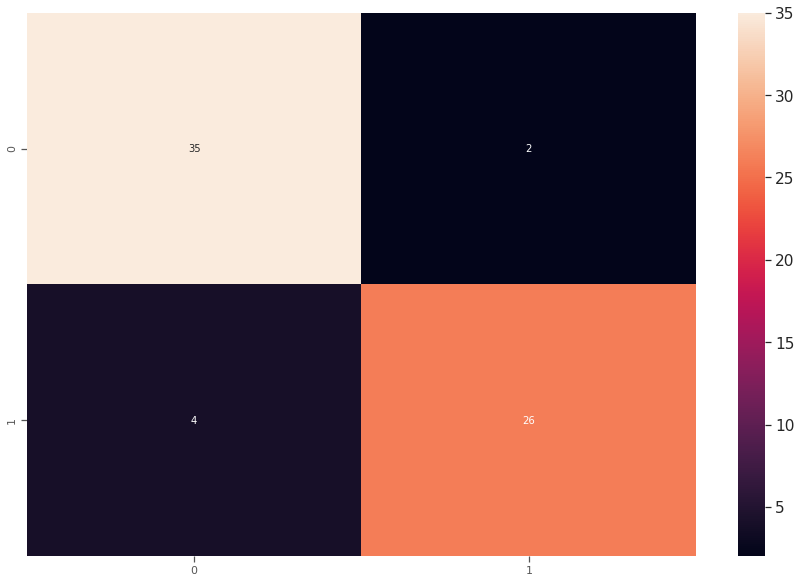

```python
conf_matrix(conf_matrix_list, f1_list)
```

Pela matriz de confusão podemos observar que o algoritmo classifica bem o problema, tendo poucos falsos positivos e também poucos falsos negativos (no entanto possuindo dois falso negativos a mais do que os falsos positivos).

```python
index_best = f1_list.index(max(f1_list))
class_repo_list_best = class_repo_list[index_best]

print(class_repo_list_best)
```

```
              precision    recall  f1-score   support

           0       0.90      0.95      0.92        37
           1       0.93      0.87      0.90        30

    accuracy                           0.91        67
   macro avg       0.91      0.91      0.91        67
weighted avg       0.91      0.91      0.91        67
```

## SVM

As máquinas vetoriais de suporte (SVMs) são um conjunto de métodos de aprendizagem supervisionada usados para classificação, regressão e detecção de anomaliaz.

As vantagens das máquinas vetoriais de suporte são:

- Eficazes em espaços de alta dimensão.
- Ainda eficazes nos casos em que o número de dimensões é maior do que o número de amostras.
- Utiliza um subconjunto de pontos de treinamento na função de decisão (chamados vetores de suporte), portanto, também é eficiente em termos de memória.
- Versátil: diferentes funções do Kernel podem ser especificadas para a função de decisão. São fornecidos núcleos comuns, mas também é possível especificar núcleos personalizados.

As desvantagens das máquinas vetoriais de suporte incluem:

Abaixo iremos instanciar um modelo SVM para usar nos nossos dados de Credit Approval.

```python
from sklearn.svm import SVC
from sklearn import preprocessing

X = data_dummified.drop("A16", axis=1)
y = data_dummified["A16"]

X = X.values
X = preprocessing.scale(X)

y = y.values

svm = SVC()
grid_params = {'C':[1,10],'gamma':[1,0.1], 'kernel':['linear','rbf']}

best_params, best_score, results = grid_search(svm, grid_params,10, X,y)
```

```python
best_score
```

```
0.8707532407325074
```

```python
svm_best = best_params
print("Melhores parâmetros: {}".format(svm_best))
```

```
Melhores parâmetros: {'C': 1, 'gamma': 1, 'kernel': 'linear'}
```

### Usando K-Fold e normalizando os dados

```python
svm = SVC(**svm_best)
acc_list, conf_matrix_list, f1_list, class_repo_list, modelos = KFolds_norm(data_dummified, svm)
```

```
StratifiedKFold(n_splits=10, random_state=11, shuffle=True)
--------------------------------------------------------
Fold número:  1
Tamanho do X_train: (603, 36)
Acurácia:  0.9117647058823529
f1-score:  0.9032258064516129
--------------------------------------------------------
Fold número:  2
Tamanho do X_train: (604, 36)
Acurácia:  0.9253731343283582
f1-score:  0.923076923076923
--------------------------------------------------------
Fold número:  3
Tamanho do X_train: (604, 36)
Acurácia:  0.8059701492537313
f1-score:  0.7868852459016393
--------------------------------------------------------
Fold número:  4
Tamanho do X_train: (604, 36)
Acurácia:  0.8955223880597015
f1-score:  0.8955223880597014
--------------------------------------------------------
Fold número:  5
Tamanho do X_train: (604, 36)
Acurácia:  0.9104477611940298
f1-score:  0.9032258064516129
--------------------------------------------------------
Fold número:  6
Tamanho do X_train: (604, 36)
Acurácia:  0.7910447761194029
f1-score:  0.8
--------------------------------------------------------
Fold número:  7
Tamanho do X_train: (604, 36)
Acurácia:  0.835820895522388
f1-score:  0.835820895522388
--------------------------------------------------------
Fold número:  8
Tamanho do X_train: (604, 36)
Acurácia:  0.835820895522388
f1-score:  0.8450704225352113
--------------------------------------------------------
Fold número:  9
Tamanho do X_train: (604, 36)
Acurácia:  0.8208955223880597
f1-score:  0.8235294117647058
--------------------------------------------------------
Fold número:  10
Tamanho do X_train: (604, 36)
Acurácia:  0.835820895522388
f1-score:  0.8253968253968254
Terminado
```

```python
print(max(acc_list))
print(max(f1_list))

dict_results['svm_acc'] = max(acc_list)
dict_results['svm_f1'] = max(f1_list)
```

```
0.9253731343283582
0.923076923076923
```

O score f1 da svm é ligeiramente maior do que o do algoritmo knn, sendo 0.923076

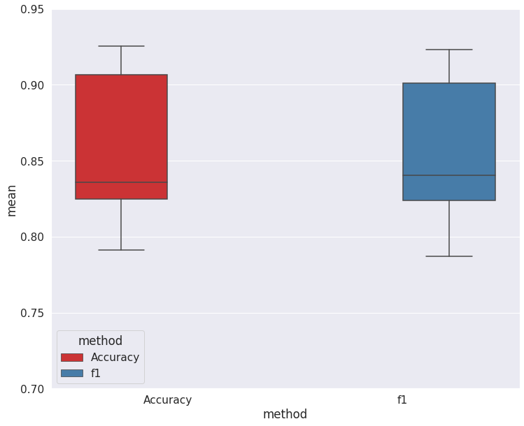

```python
boxplot_results(acc_list, f1_list)
```

Observando seus boxplots também podemos afirmar que a variância do cv é maior no svm

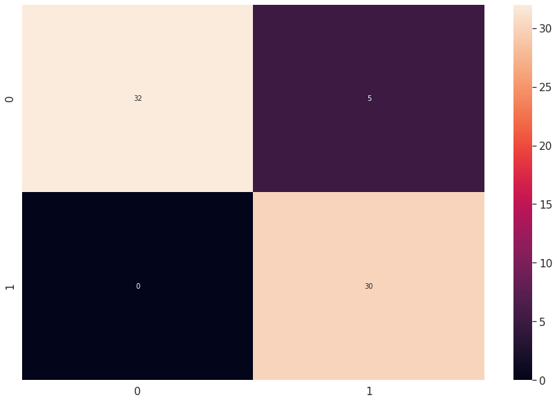

```python
conf_matrix(conf_matrix_list, f1_list)
```

```python
index_best = f1_list.index(max(f1_list))
class_repo_list_best = class_repo_list[index_best]

print(class_repo_list_best)
```

```
              precision    recall  f1-score   support

           0       1.00      0.86      0.93        37
           1       0.86      1.00      0.92        30

    accuracy                           0.93        67
   macro avg       0.93      0.93      0.93        67
weighted avg       0.94      0.93      0.93        67
```

## Random Forest

Florestas aleatórias ou florestas de decisão aleatória são um método de aprendizagem em conjunto para classificação, regressão e outras tarefas que operam através da construção de uma multiplicidade de árvores de decisão em tempo de treinamento e produzindo a classe que é o modo das classes (classificação) ou previsão de média/ média (regressão) das árvores individuais. Florestas de decisão aleatória corrigem o hábito das árvores de decisão de se ajustarem em excesso ao seu conjunto de treinamento. Florestas aleatórias geralmente superam as árvores de decisão, mas sua precisão é menor do que as árvores de decisão de gradiente. Entretanto, as características dos dados podem afetar seu desempenho.

```python
from sklearn.ensemble import RandomForestClassifier

X = data_dummified.drop("A16", axis=1)
y = data_dummified["A16"]

X = X.values
#X = preprocessing.scale(X)

y = y.values

n_estimators = [5, 10, 25, 50]
# Number of features to consider at every split
crit = ['gini', 'entropy']
# Maximum number of levels in tree
max_depth = [8,9,10]
# Minimum number of samples required to split a node
min_samples_split = [2,5]
# Minimum number of samples required at each leaf node
min_samples_leaf = [1,2]
# Method of selecting samples for training each tree
bootstrap = [True, False]# Create the random grid
grid_params = {'n_estimators': n_estimators,
               'criterion': crit,
               'max_depth': max_depth,
               'min_samples_split': min_samples_split,
               'min_samples_leaf': min_samples_leaf,
               'bootstrap': bootstrap}

# Create a based model
rf = RandomForestClassifier()# Instantiate the grid search model

best_params, best_score, results = grid_search(rf, grid_params,10, X,y)
```

```python
best_score
```

```
0.8584518720819219
```

```python
rf_best = best_params
print("Melhores parâmetros: {}".format(rf_best))
```

```
Melhores parâmetros: {'bootstrap': True, 'criterion': 'entropy', 'max_depth': 8, 'min_samples_leaf': 2, 'min_samples_split': 5, 'n_estimators': 10}
```

### Usando K-Fold e normalizando os dados

```python
rf = RandomForestClassifier(**rf_best)
acc_list, conf_matrix_list, f1_list, class_repo_list, modelos = KFolds_norm(data_dummified, rf)
```

```
StratifiedKFold(n_splits=10, random_state=11, shuffle=True)
--------------------------------------------------------
Fold número:  1
Tamanho do X_train: (603, 36)
Acurácia:  0.8970588235294118
f1-score:  0.888888888888889
--------------------------------------------------------
Fold número:  2
Tamanho do X_train: (604, 36)
Acurácia:  0.835820895522388
f1-score:  0.8
--------------------------------------------------------
Fold número:  3
Tamanho do X_train: (604, 36)
Acurácia:  0.8507462686567164
f1-score:  0.8333333333333334
--------------------------------------------------------
Fold número:  4
Tamanho do X_train: (604, 36)
Acurácia:  0.8656716417910447
f1-score:  0.8421052631578948
--------------------------------------------------------
Fold número:  5
Tamanho do X_train: (604, 36)
Acurácia:  0.8805970149253731
f1-score:  0.8620689655172413
--------------------------------------------------------
Fold número:  6
Tamanho do X_train: (604, 36)
Acurácia:  0.8805970149253731
f1-score:  0.8666666666666667
--------------------------------------------------------
Fold número:  7
Tamanho do X_train: (604, 36)
Acurácia:  0.8805970149253731
f1-score:  0.8571428571428571
--------------------------------------------------------
Fold número:  8
Tamanho do X_train: (604, 36)
Acurácia:  0.8507462686567164
f1-score:  0.84375
--------------------------------------------------------
Fold número:  9
Tamanho do X_train: (604, 36)
Acurácia:  0.8805970149253731
f1-score:  0.8620689655172413
--------------------------------------------------------
Fold número:  10
Tamanho do X_train: (604, 36)
Acurácia:  0.8955223880597015
f1-score:  0.8923076923076922
Terminado
```

```python
print(max(acc_list))
print(max(f1_list))

dict_results['rf_acc'] = max(acc_list)
dict_results['rf_f1'] = max(f1_list)
```

```
0.8970588235294118
0.8923076923076922
```

A random forest não obteve um score f1 melhor do que o modelo de svm nem do que o de knn

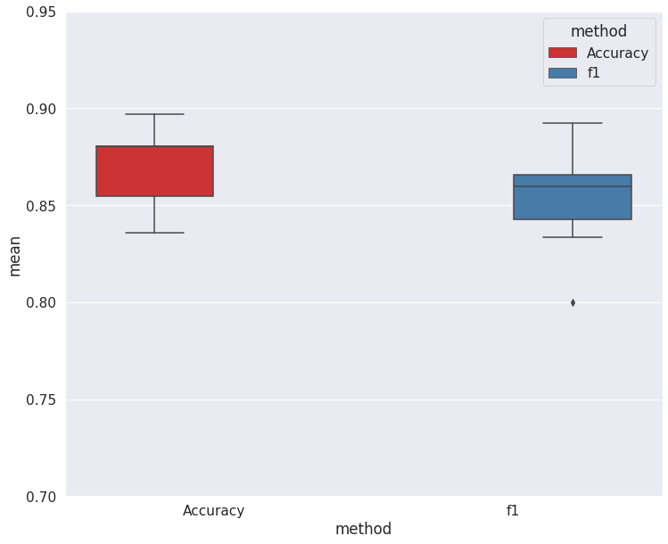

```python
boxplot_results(acc_list, f1_list)
```

Sua variância no cv no entanto é relativamente baixa

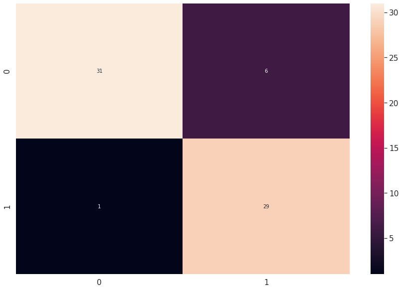

```python
conf_matrix(conf_matrix_list, f1_list)
```

No caso da random forest ele se assemelha ao svm, pois quase não possui falsos negativos, mas possui falsos positivos em pequeno número.

```python
index_best = f1_list.index(max(f1_list))
class_repo_list_best = class_repo_list[index_best]

print(class_repo_list_best)
```

```
              precision    recall  f1-score   support

           0       0.97      0.84      0.90        37
           1       0.83      0.97      0.89        30

    accuracy                           0.90        67
   macro avg       0.90      0.90      0.90        67
weighted avg       0.91      0.90      0.90        67
```

## Decision Tree

As árvores de decisão (DTs) são um método de aprendizagem supervisionado não paramétrico utilizado para classificação e regressão. O objetivo é criar um modelo que preveja o valor de uma variável alvo através do aprendizado de regras de decisão simples inferidas a partir das características dos dados. Uma árvore pode ser vista como uma aproximação constante por partes.

Algumas vantagens das árvores de decisão são:

- Simples de entender e de interpretar. As árvores podem ser visualizadas.
- Requer pouca preparação de dados. Outras técnicas muitas vezes requerem normalização dos dados, variáveis fictícias precisam ser criadas e valores em branco precisam ser removidos. Observe, entretanto, que este módulo não suporta valores ausentes.
- O custo de usar a árvore (isto é, prever dados) é logarítmico no número de pontos de dados usados para treinar a árvore.
- Utiliza um modelo de caixa branca. Se uma determinada situação é observável em um modelo, a explicação da condição é facilmente explicada pela lógica booleana. Em contraste, em um modelo de caixa preta (por exemplo, em uma rede neural artificial), os resultados podem ser mais difíceis de interpretar.
- É possível validar um modelo usando testes estatísticos. Isso torna possível contabilizar a confiabilidade do modelo.
- Funciona bem mesmo que suas suposições sejam de alguma forma violadas pelo modelo verdadeiro a partir do qual os dados foram gerados.

```python
from sklearn.tree import DecisionTreeClassifier


X = data_dummified.drop("A16", axis=1)
y = data_dummified["A16"]

X = X.values

#X = preprocessing.scale(X)

y = y.values


param_grid = { 'criterion':['gini','entropy'],'max_depth': np.arange(3, 15)}
dtree = DecisionTreeClassifier()
best_params, best_score, results = grid_search(dtree, param_grid, 10, X, y)
```

```python
best_score
```

```
0.8514729557631217
```

```python
dtree_best = best_params
print("Melhores parâmetros: {}".format(dtree_best))
```

```
Melhores parâmetros: {'criterion': 'entropy', 'max_depth': 5}
```

### Usando K-Fold e Normalizando os dados

```python
dtree = DecisionTreeClassifier(**dtree_best)
acc_list, conf_matrix_list, f1_list, class_repo_list, modelos = KFolds_norm(data_dummified, dtree)
```

```
StratifiedKFold(n_splits=10, random_state=11, shuffle=True)
--------------------------------------------------------
Fold número:  1
Tamanho do X_train: (603, 36)
Acurácia:  0.7647058823529411
f1-score:  0.7333333333333333
--------------------------------------------------------
Fold número:  2
Tamanho do X_train: (604, 36)
Acurácia:  0.835820895522388
f1-score:  0.819672131147541
--------------------------------------------------------
Fold número:  3
Tamanho do X_train: (604, 36)
Acurácia:  0.8507462686567164
f1-score:  0.8484848484848485
--------------------------------------------------------
Fold número:  4
Tamanho do X_train: (604, 36)
Acurácia:  0.835820895522388
f1-score:  0.8253968253968254
--------------------------------------------------------
Fold número:  5
Tamanho do X_train: (604, 36)
Acurácia:  0.9253731343283582
f1-score:  0.9180327868852459
--------------------------------------------------------
Fold número:  6
Tamanho do X_train: (604, 36)
Acurácia:  0.8656716417910447
f1-score:  0.847457627118644
--------------------------------------------------------
Fold número:  7
Tamanho do X_train: (604, 36)
Acurácia:  0.8208955223880597
f1-score:  0.8064516129032259
--------------------------------------------------------
Fold número:  8
Tamanho do X_train: (604, 36)
Acurácia:  0.9701492537313433
f1-score:  0.967741935483871
--------------------------------------------------------
Fold número:  9
Tamanho do X_train: (604, 36)
Acurácia:  0.8656716417910447
f1-score:  0.8421052631578948
--------------------------------------------------------
Fold número:  10
Tamanho do X_train: (604, 36)
Acurácia:  0.8955223880597015
f1-score:  0.8852459016393444
Terminado
```

```python
print(max(acc_list))
print(max(f1_list))

dict_results['dtree_acc'] = max(acc_list)
dict_results['dtree_f1'] = max(f1_list)
```

```
0.9701492537313433
0.967741935483871
```

O resultado do score f1 da árvore de decisão foi melhor do que os dos modelos anteriores.

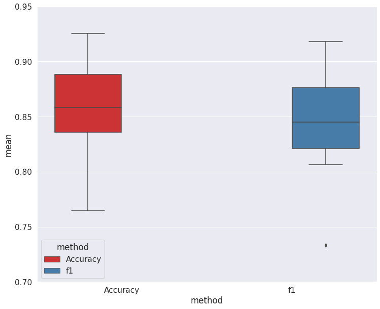

```python
boxplot_results(acc_list, f1_list)
```

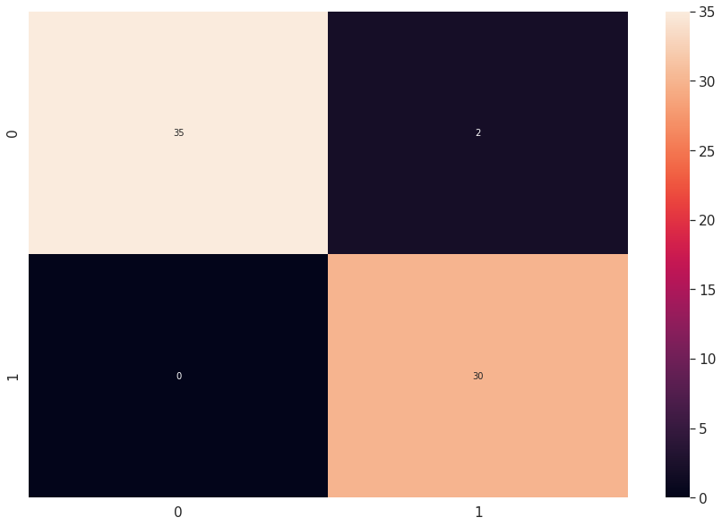

```python
conf_matrix(conf_matrix_list, f1_list)
```

No caso da árvore de decisão houve uma diminuição nos falsos negativos para zero e uma siminuição também nos falsos positivos em relação ao modelo de random forest, esse modelo também se mostra mais equilibrado entre os falsos positivos e falsos negativos ainda mantendo um score baixo para os mesmos.

```python
index_best = f1_list.index(max(f1_list))
class_repo_list_best = class_repo_list[index_best]

print(class_repo_list_best)
```

```
              precision    recall  f1-score   support

           0       1.00      0.95      0.97        37
           1       0.94      1.00      0.97        30

    accuracy                           0.97        67
   macro avg       0.97      0.97      0.97        67
weighted avg       0.97      0.97      0.97        67
```

### Feature Importance

Com a árvore de decisão iremos avaliar a importância das features selecionadas para o modelo.

```python
index_best = f1_list.index(max(f1_list))
final_dtree = modelos[index_best]
```

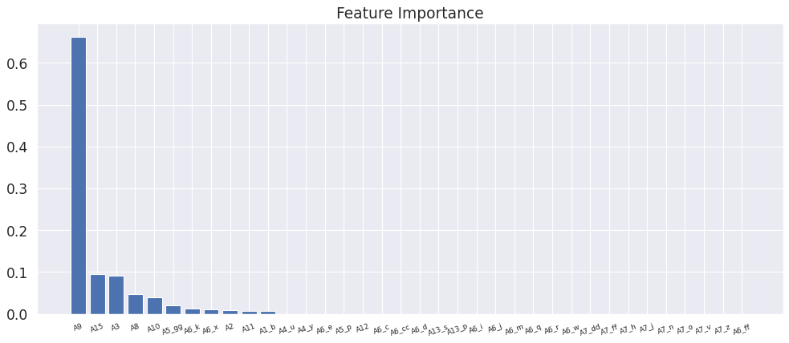

```python
X = data_dummified.drop("A16", axis=1)
y = data_dummified["A16"]

importances = final_dtree.feature_importances_
# Sort feature importances in descending order
indices = np.argsort(importances)[::-1]

# Rearrange feature names so they match the sorted feature importances
names = [X.columns[i] for i in indices]

plt.figure(figsize=(15, 6), dpi=80)
# Barplot: Add bars
plt.bar(range(X.shape[1]), importances[indices])
# Add feature names as x-axis labels
plt.xticks(range(X.shape[1]), names, rotation=20, fontsize = 8)
# Create plot title
plt.title("Feature Importance")
# Show plot
plt.show()
```

Aqui vemos que apenas as colunas

```
A9, A15, A3, A8, A10, A5_gg, A6_k, A6_x, A2, A11 e A1_b
```

São realmente relevantes para o modelo, sendo a coluna A9 (PriorDefault) a mais relevante dentre todas. É interessante notar que todas as variáveis contínuas foram incluidas como relevantes.

A variável A15 (Income), a A3 (Debt), a A8 (YearsEmployed) e a A10 (Employed) também se destacam, são variáveis interessantes pois realmente são o que se espera que um modelo de avaliação de crédito leve em consideração.

### Melhor modelo?

```python
for key, value in dict_results.items():
    if key.split('_')[1] == "f1":
        print("{} : {}".format(key,value))
```

```
knn_f1 : 0.896551724137931
svm_f1 : 0.923076923076923
rf_f1 : 0.8923076923076922
dtree_f1 : 0.967741935483871
```

Os modelos, em geral, possuem valores de f1 bastante semelhantes, no entanto caso fosse necessário trabalhar apenas com um e tivessemos que escolher pelo f1 a decision tree se destaca.

Porém, por eles serem tão semelhantes, é interessante olhar também para a matriz de confusão para fazer a escolha de qual modelo efetivamente usar. Para todos os casos (menor falso positivo ou negativo, ou maior equilibrio entre os dois mas ainda os minimizando) no entanto a árvore de decisão segue sendo a melhor escolha, dado que possui 0 falsos negativos e 2 falsos positivos.

Por exemplo, no entanto, se não a levarmos em consideração e levantarmos a hipótese de que queremos um modelo cujo ponto forte é não ter nenhum falso negativo podemos escolher o svm (entendendo que todo erro que tivermos provavelmente seria um falso positivo).

Para esse problema em questão seria mais interessante minimizarmos os falsos positivos, pois são pessoas cujo crédito não deveria ser aprovado mas é, portanto fazendo com que provavelmente se perca mais dinheiro com esses falsos positivos do que com falsos negativos, assim, nesse cenário (supondo que o modelo de árvore de decisão não exista) o melhor modelo seria o de knn.